# task5

By using forecasting techniques, e-commerce platforms like Flipkart, Amazon India, and Meesho can ensure better resource allocation and reduce risks related to stock shortages or overstocking.

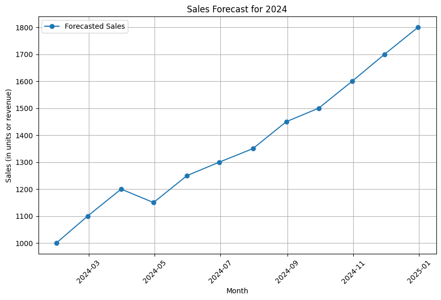

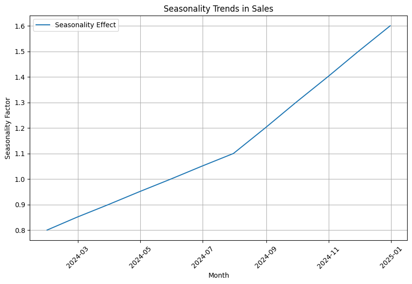

```python
import matplotlib.pyplot as plt
import pandas as pd

# Example data (replace with actual forecast data)
dates = pd.date_range(start='2024-01-01', periods=12, freq='M')
forecast_sales = [1000, 1100, 1200, 1150, 1250, 1300, 1350, 1450, 1500, 1600, 1700, 1800]

# Create a DataFrame
df_forecast = pd.DataFrame({'Date': dates, 'Sales': forecast_sales})

# Plot the forecasted sales trend
plt.figure(figsize=(10,6))
plt.plot(df_forecast['Date'], df_forecast['Sales'], marker='o', label='Forecasted Sales')
plt.title('Sales Forecast for 2024')
plt.xlabel('Month')
plt.ylabel('Sales (in units or revenue)')
plt.grid(True)
plt.xticks(rotation=45)
plt.legend()
plt.show()

# Example for seasonality: Plot seasonal component if available
seasonality = [0.8, 0.85, 0.9, 0.95, 1.0, 1.05, 1.1, 1.2, 1.3, 1.4, 1.5, 1.6]  # Hypothetical seasonal effects
plt.figure(figsize=(10,6))
plt.plot(dates, seasonality, label='Seasonality Effect')
plt.title('Seasonality Trends in Sales')
plt.xlabel('Month')
plt.ylabel('Seasonality Factor')
plt.grid(True)
plt.xticks(rotation=45)
plt.legend()
plt.show()
```

2️⃣ Sales Forecasting Visualizations (Charts & Graphs)

Line chart comparing historical sales vs. predicted sales. Bar chart or heatmap highlighting peak sales periods and slow months. Trend analysis graph showcasing long-term sales growth or decline.

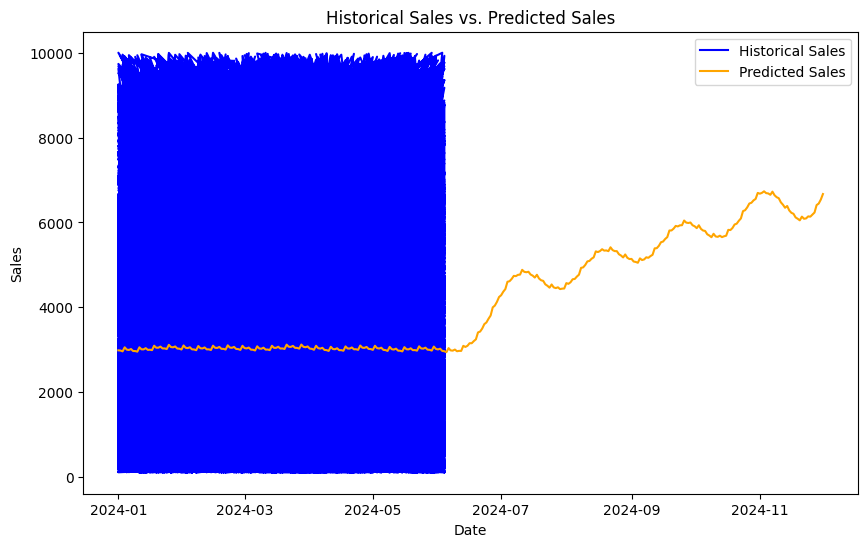

```python
#1. Line Chart: Historical Sales vs. Predicted Sales
import matplotlib.pyplot as plt

# Assuming df contains historical sales data and forecasted sales is in 'forecast'
plt.figure(figsize=(10, 6))

# Historical Sales
plt.plot(df['Purchase Date'], df['Total Sales'], label='Historical Sales', color='blue')

# Predicted Sales (replace this with your forecast data)
plt.plot(forecast['ds'], forecast['yhat'], label='Predicted Sales', color='orange')

# Title and Labels
plt.title('Historical Sales vs. Predicted Sales')
plt.xlabel('Date')
plt.ylabel('Sales')
plt.legend()

# Display the plot
plt.show()
```

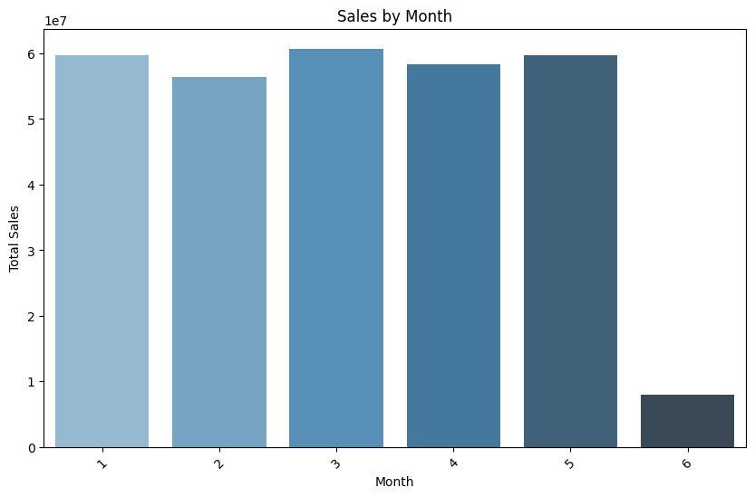

```python
#2. Bar Chart or Heatmap: Highlighting Peak Sales Periods and Slow MonthsFor a bar chart, you can group sales by month and show the total sales for each month.

import seaborn as sns

# Grouping by month for total sales (assuming 'Purchase Date' is datetime and 'Total Sales' is numeric)
df['Month'] = df['Purchase Date'].dt.month
monthly_sales = df.groupby('Month')['Total Sales'].sum()

# Plotting the bar chart
plt.figure(figsize=(10, 6))
sns.barplot(x=monthly_sales.index, y=monthly_sales.values, palette='Blues_d')
plt.title('Sales by Month')
plt.xlabel('Month')
plt.ylabel('Total Sales')
plt.xticks(rotation=45)
plt.show()
```